# Process SC Data

RG

2023-05-28

## Download and Process the Data

FIXME: we should update this to more modern workflows. Somehow there is no filtering going on, wrt, the counts matrix, which should be made smaller.

```
## snapshotDate(): 2022-10-31
```

```
## see ?DropletTestFiles and browseVignettes('DropletTestFiles') for documentation
```

```
## loading from cache
```

```
## 'as(<dgTMatrix>, "dgCMatrix")' is deprecated.
## Use 'as(., "CsparseMatrix")' instead.
## See help("Deprecated") and help("Matrix-deprecated").
```

## Some Ideas from Mardia Kent and Bibby

- one measure of variable importance can be ascertained from the PCs. For PC1, for example, any feature (gene) that has a large *loading* on PC1 is likely to be important in understanding the variation in that direction
- one could look at the highly variable genes and see what their loadings are in each of the PCs

```
##    Mode   FALSE    TRUE
## logical    3985     315
```

scDBLfinder

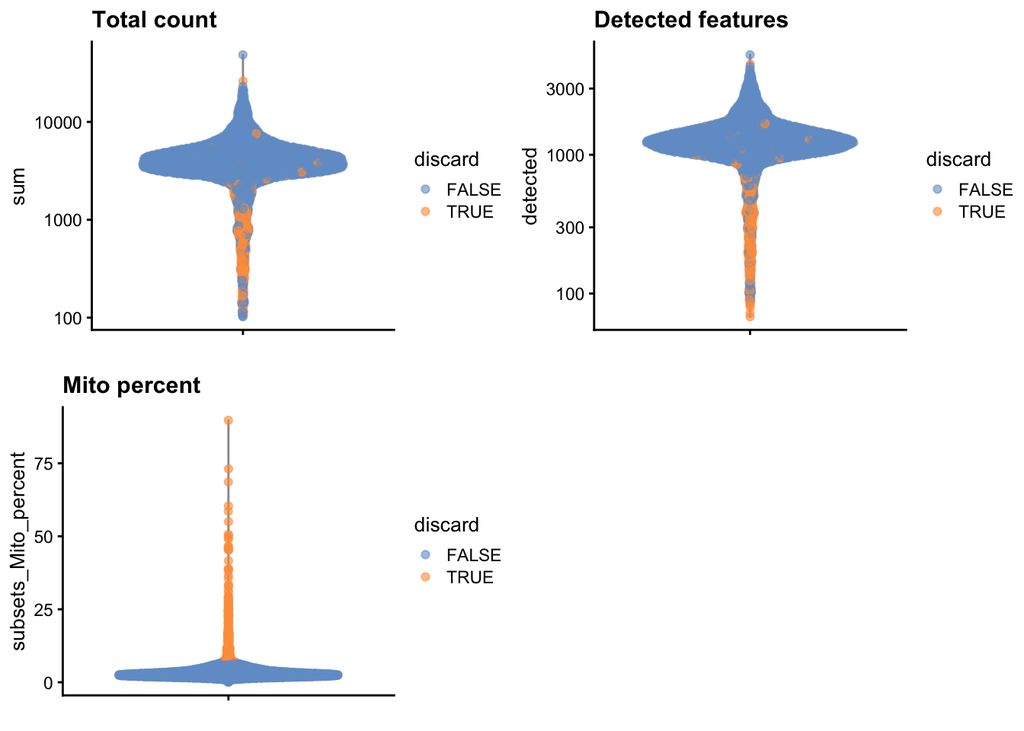

```
##     Min.  1st Qu.   Median     Mean  3rd Qu.     Max.
##  0.00749  0.71207  0.87490  1.00000  1.09900 12.25412
```

```
## [1] 9
```

Now let’s have a look at what we got

## Break

```r
##Extract the computed PCs
pcs <- getDenoisedPCs(sce.pbmc, subset.row=top.pbmc, technical=dec.pbmc)
##components is the matrix of rotated per cell
dim(pcs$components)
```

```
## [1] 3985    9
```

```r
##and rotation is the matrix of PC directions
dim(pcs$rotation)
```

```
## [1] 1599    9
```

And now save the appropriate things for loading up later.

```r
save(pcs, file="pcs.rda")
save(sce.pbmc, file="sce.pbmc.rda")
```